#### Capstone Project of Coursera Data Science Specialisation

#### Spring 2015 Edition

#### Author: Iga Korneta

**Executive Summary**: This report details the results of my exploratory analysis of the corpus of English-language files used in the Capstone project. **For the sake of clarity, the code for the more calculation-intensive parts of the processing / report is listed below the main text.**

**File sizes, word counts, line counts**: The corpus contains three plaintext files. The following table contains basic information about the files in the corpus:

| File Name | File Size | Word Count | Line Count |
| --- | --- | --- | --- |
| en_US.blogs.txt | 200MB | 37,214,743 | 899288 |
| en_US.news.txt | 196MB | 2,634,910 | 77259 |
| en_US.twitter.txt | 159MB | 29,763,605 | 2360148 |
| ——— | ——— | ———- | ———- |
| **Sum** |  | 69,613,258 |  |

**Sampling the data**: Due to size of the corpus, the fact that I’m doing the project on a shitty laptop; as well as the fact that, as per Task 1 description, this is allowed - for the rest of the analysis (calculating the term frequencies and n-grams), for the sake of this analysis, I decided to work on a random sample of 5% of the data.

The most popular terms and other summaries are listed below:

```r
library(ggplot2)
library(NLP)
library(tm)
library(RColorBrewer)
library(wordcloud)
freq.data.frame <- read.csv("./data/corpsample_cleaned_nostopwords_termfreq.txt")
ord.freq.data.frame <- freq.data.frame[order(freq.data.frame$freq, decreasing=TRUE),]
```

Most popular **non-stop** words in the cleaned sample:

```r
head(ord.freq.data.frame, n=10)
```

```
##             X freq
## 29221    dont 7552
## 42835    good 7490
## 106113   time 7381
## 25176     day 7164
## 61590    love 7161
## 7172     back 5534
## 78108  people 5436
## 43650   great 5289
## 62860    make 4991
## 106614  today 4691
```

Wordcloud of the most popular words:

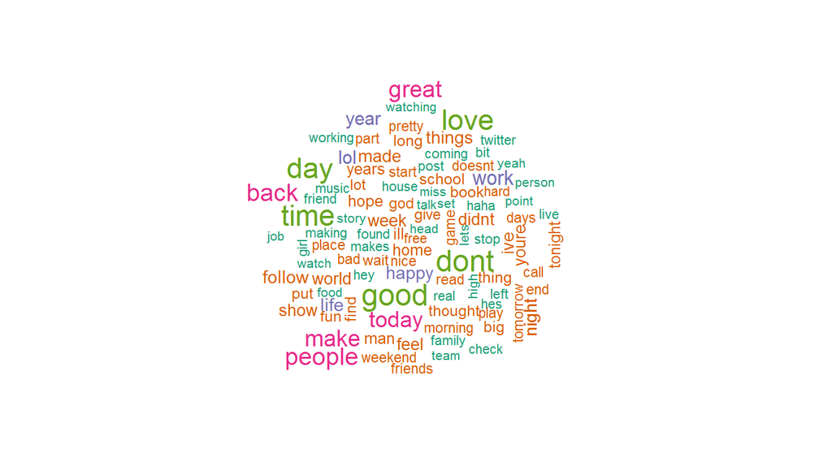

```r
wordcloud(freq.data.frame$X, freq.data.frame$freq, max.words=100, scale=c(1.5, .5), colors=brewer.pal(5, "Dark2"))
```

Histogram of the number of words appearing at a given count (warning: log scale on the Y-axis):

```
## Warning: Stacking not well defined when ymin != 0
```

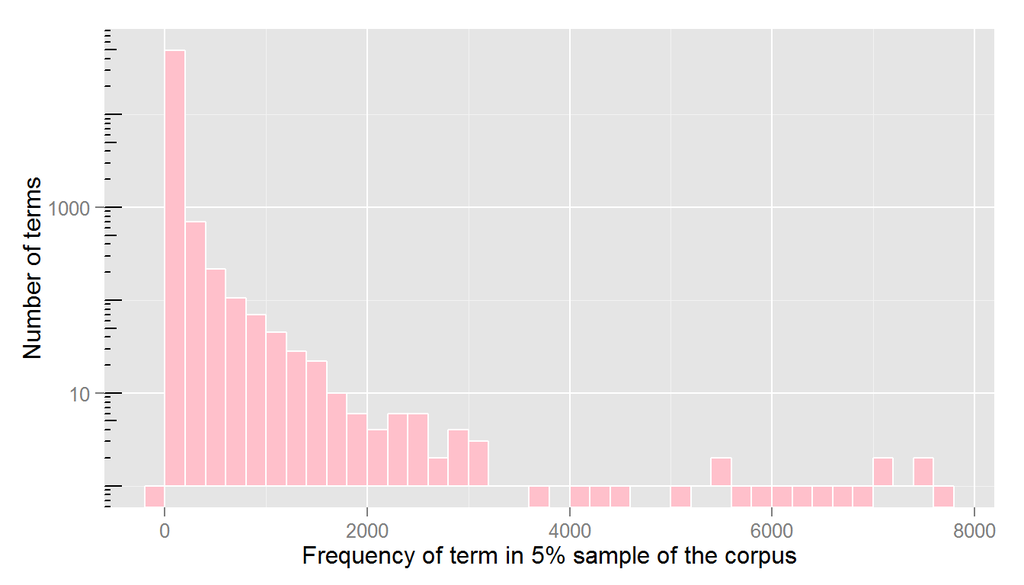

```r
temp <- freq.data.frame[freq.data.frame$freq>1,]
p <- ggplot(temp, aes(freq))
p <- p + geom_histogram(binwidth=200, fill="pink", colour="white")
p <- p + scale_y_log10() + annotation_logticks(sides="l")
p <- p + ylab("Number of terms") +  xlab("Frequency of term in 5% sample of the corpus")
p
```

**2- and 3-grams**: Finally, as per the Task 2 description, I decided to find out the frequencies of 2- and 3-grams in the sample. The sample contained 1,135,347 distinct 2-grams and 2,315,421 distinct 3-grams, out of which 254,669 2-grams and 229,282 3-grams appeared more than once. 8,223 2-grams were needed to obtain 50% coverage of all 2-grams appearing more than once, while 33,365 3-grams were needed to obtain 50% coverage.

```r
freq2.data.frame <- read.csv("./data/corpsample_cleaned_withstopwords_termfreq_2grams.txt")
ord.freq2.data.frame <- freq2.data.frame[order(freq2.data.frame$freq, decreasing=TRUE),]
freq3.data.frame <- read.csv("./data/corpsample_cleaned_withstopwords_termfreq_3grams.txt")
ord.freq3.data.frame <- freq3.data.frame[order(freq3.data.frame$freq, decreasing=TRUE),]
```

The most popular 2-grams were as follows:

```r
head(ord.freq2.data.frame, n=10)
```

```
##               X  freq
## 677826   of the 12846
## 478892   in the 12235
## 1005830  to the  6854
## 358101  for the  6771
## 689681   on the  6351
## 997930    to be  5863
## 93219    at the  4426
## 461779   i have  3896
## 63307   and the  3854
## 463484    i was  3797
```

Wordcloud of the most popular 2-grams:

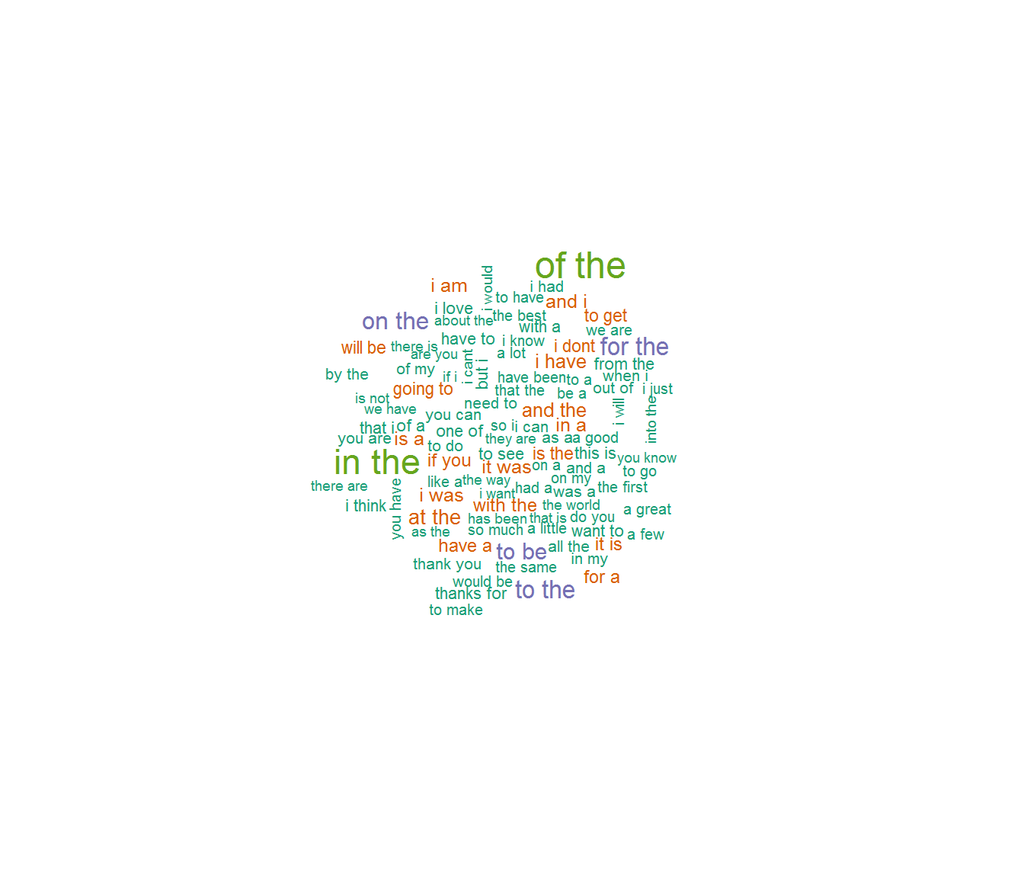

```r
wordcloud(freq2.data.frame$X, freq2.data.frame$freq, max.words=100, scale=c(1.5, .5), colors=brewer.pal(5, "Dark2"))
```

Histogram of the number of 2-grams appearing at a given count (warning: log scale on the Y-axis):

```
## Warning: Stacking not well defined when ymin != 0
```

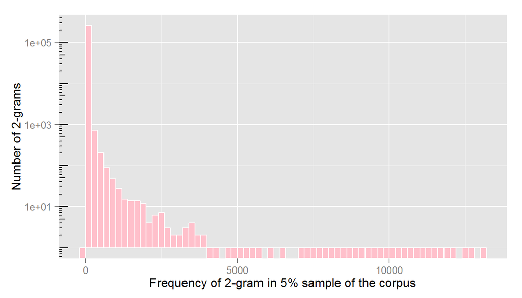

```r
temp <- freq2.data.frame[freq2.data.frame$freq>1,]
p <- ggplot(temp, aes(freq))
p <- p + geom_histogram(binwidth=200, fill="pink", colour="white")
p <- p + scale_y_log10() + annotation_logticks(sides="l")
p <- p + ylab("Number of 2-grams") +  xlab("Frequency of 2-gram in 5% sample of the corpus")
p
```

The most popular 3-grams were as follows:

```r
head(ord.freq3.data.frame, n=10)
```

```
##                          X freq
## 1801462     thanks for the 1238
## 1392209         one of the 1064
## 25005             a lot of 1050
## 1992813            to be a  659
## 905433           i want to  643
## 747415         going to be  622
## 894027           i have to  542
## 1800492      thank you for  536
## 1127338 looking forward to  530
## 1017109           it was a  521
```

Wordcloud of the most popular 3-grams:

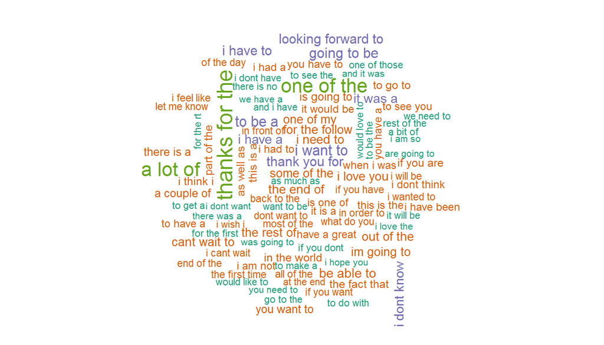

```r
wordcloud(freq3.data.frame$X, freq3.data.frame$freq, max.words=100, scale=c(1.5, .5), colors=brewer.pal(5, "Dark2"))
```

Histogram of the number of 3-grams appearing at a given count (warning: log scale on the Y-axis):

```
## Warning: Stacking not well defined when ymin != 0
```

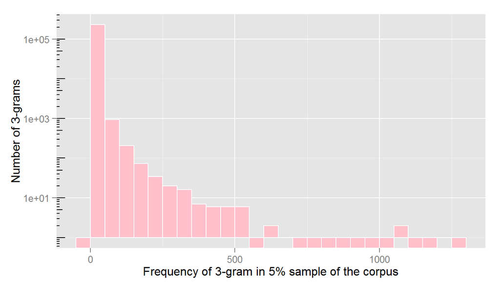

```r
temp <- freq3.data.frame[freq3.data.frame$freq>1,]
p <- ggplot(temp, aes(freq))
p <- p + geom_histogram(binwidth=50, fill="pink", colour="white")
p <- p + scale_y_log10() + annotation_logticks(sides="l")
p <- p + ylab("Number of 3-grams") +  xlab("Frequency of 3-gram in 5% sample of the corpus")
p
```

**Conclusion:** The results of this phase of my exploratory analysis indicate that the English language is very power-law-like: i.e. there are a few words that are ubiquitous, and a lot that are very sparsely used. The ubiquitous are so ubiquitous that it should be hard to predict the word following the previous one, because there are so many possibilities, while the sparse are difficult to predict because there are so few possibilities. Hence, attention should be focused on the “happy middle” - words present in the language in relatively fixed associations / compounds / fixed phrases.

**Code**: Word and line counts:

```r
library(qdap)
cname <- "./data/"
docs <- Corpus(DirSource(cname)) #doc1 is blogs, doc2 is news, doc3 is twitter

length(content(docs[[1]])) #line count of blogs
word_count(content(docs[[1]]), digit.remove=FALSE, byrow=FALSE) #word count of blogs
content(docs[[1]])[1:5] #first five lines of blogs
```

Sampling:

```r
set.seed(123)
binom <- rbinom(899288+77259+2360148, 1, 0.05)
corpsample <- c(content(docs[[1]])[binom[1:899288]==1], content(docs[[2]])[binom[899289:976547]==1], content(docs[[3]])[binom[976548:3336695]==1])

con <- file("./data/corpsample.txt", open="wt")
writeLines(corpsample, con)
close(con)

rm(list=ls())
```

Cleaning the data sample for term frequency calculations:

```r
corpsample <- PlainTextDocument(readLines("./data/corpsample.txt"))
corpsample <- tolower(corpsample)
corpsample <- removeNumbers(corpsample)
corpsample <- removePunctuation(corpsample)
corpsample <- gsub("[â]","", corpsample)
corpsample <- stemDocument(corpsample)
corpsample <- removeWords(corpsample, stopwords("SMART")) #cleaning for n-grams is identical with the exclusion of this one line
corpsample <- stripWhitespace(corpsample)

con <- file("./data/corpsample_cleaned_nostopwords.txt", open="wt")
writeLines(corpsample, con)
close(con)
```

Term frequency calculations:

```r
corpsample <- PlainTextDocument(readLines("./data/corpsample_cleaned_nostopwords.txt"))
freq <- termFreq(corpsample)
freq.data.frame <- as.data.frame(freq)
write.csv(freq.data.frame,"./data/corpsample_cleaned_nostopwords_termfreq.txt")
```

Term frequency summaries:

```r
freq.data.frame <- read.csv("./data/corpsample_cleaned_nostopwords_termfreq.txt")
ord.freq.data.frame <- freq.data.frame[order(freq.data.frame$freq, decreasing=TRUE),]

dim(freq.data.frame)[1]
nrow(freq.data.frame[freq.data.frame$freq>1,])

#coverage calculations begin below
df <- as.data.frame(table(freq.data.frame[freq.data.frame$freq>1,]$freq))
totinst <- sum(as.numeric(as.character(df[,1]))*df[,2])
csum <- 0
a50 <- 0
a90 <- 0

for (i in dim(df)[1]:1){
  csum= csum + as.numeric(as.character(df[i,1]))*df[i,2]
  if ((csum/totinst > 0.5) & a50==0) {a50 <- i}
  if ((csum/totinst > 0.9) & a90==0) {a90 <- i}
  }
sum(df[a50:dim(df)[1],2])
sum(df[a90:dim(df)[1],2])
```

2- and 3-gram calculations:

```r
library("RWeka")
corpsample <- PlainTextDocument(readLines("./data/corpsample_cleaned_withstopwords.txt"))
BigramTokenizer <- function(x) NGramTokenizer(x, Weka_control(min = 2, max = 2))
freq2 <- termFreq(corpsample, control = list(tokenize = BigramTokenizer))
freq2.data.frame <- as.data.frame(freq2)
write.csv(freq2.data.frame,"./data/corpsample_cleaned_withstopwords_termfreq_2grams.txt")

TrigramTokenizer <- function(x) NGramTokenizer(x, Weka_control(min = 3, max = 3))
freq3 <- termFreq(corpsample, control = list(tokenize = TrigramTokenizer))
freq3.data.frame <- as.data.frame(freq3)
write.csv(freq3.data.frame,"./data/corpsample_cleaned_withstopwords_termfreq_3grams.txt")
```

N-gram frequency summary calculations are identical to the 1-gram (term/word) summary calculations.